# INN Hotels Project

## Model performance evaluation

```python
# predicting on training set
# default threshold is 0.5, if predicted probability is greater than 0.5 the observation will be classified as 1

pred_train = lg.predict(X_train) > 0.5
pred_train = np.round(pred_train)
```

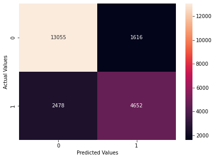

```python
cm = confusion_matrix(y_train, pred_train)
plt.figure(figsize=(7, 5))
sns.heatmap(cm, annot=True, fmt="g")
plt.xlabel("Predicted Values")
plt.ylabel("Actual Values")
plt.show()
```

#### The confusion matrix

- True Positives (TP): There are 4652 true booking cancelations.
- True Negatives (TN): There are 13055 true booking non-cancelations
- False Positives (FP): The model predicted 1616 cancelations that weren't true.
- False Negatives (FN): The model predicted 2478 non-cancelations that weren't true.

```python
# Checking accuracy of the model
print("Accuracy on training set : ", accuracy_score(y_train, pred_train))
```

```
Accuracy on training set :  0.8122104490619696
```

#### Observation:

Model performs well on the training set

## Checking Multicollinearity

- In order to make statistical inferences from a logistic regression model, it is important to ensure that there is no multicollinearity present in the data.

```python
# let's check the VIF of the predictors
vif_series = pd.Series(
    [variance_inflation_factor(X_train.values, i) for i in range(X_train.shape[1])],
    index=X_train.columns,
    dtype=float,
)
print("VIF values: \n\n{}\n".format(vif_series))
```

```
VIF values:

const                                   327.908655
no_of_adults                              1.416915
no_of_children                            2.057465
no_of_weekend_nights                      1.080413
no_of_week_nights                         1.093344
lead_time                                 1.452189
no_of_previous_cancellations              1.449943
no_of_previous_bookings_not_canceled      1.678810
avg_price_per_room                        2.408014
no_of_special_requests                    1.277716
required_car_parking_space_1              1.046544
room_type_reserved_Room_Type 2            1.112325
room_type_reserved_Room_Type 3            1.000717
room_type_reserved_Room_Type 4            1.341801
room_type_reserved_Room_Type 5            1.031898
room_type_reserved_Room_Type 6            2.011216
room_type_reserved_Room_Type 7            1.112151
arrival_year_2018                         1.514304
arrival_month_2                           2.589734
arrival_month_3                           3.095765
arrival_month_4                           3.540736
arrival_month_5                           3.596718
arrival_month_6                           4.301893
arrival_month_7                           4.014508
arrival_month_8                           4.798074
arrival_month_9                           5.816133
arrival_month_10                          6.355899
arrival_month_11                          3.767305
arrival_month_12                          3.814144
market_segment_type_Complementary         4.629482
market_segment_type_Corporate            17.019744
market_segment_type_Offline              61.068852
market_segment_type_Online               66.233153
repeated_guest_1                          1.769192
dtype: float64
```

#### Observation:

Features with VIF greater than 5 are:

- arrival_month_9
- arrival_month_10
- market_segment_type_Corporate
- market_segment_type_Offline
- market_segment_type_Online

```python
X_train2 = X_train.drop(["arrival_month_9"], axis=1)
logit = sm.Logit(y_train, X_train2.astype(float))
lg = logit.fit(
    disp=False
)  # setting disp=False will remove the information on number of iterations

print(lg.summary())
```

```
                           Logit Regression Results
==============================================================================
Dep. Variable:         booking_status   No. Observations:                21801
Model:                          Logit   Df Residuals:                    21768
Method:                           MLE   Df Model:                           32
Date:                Fri, 13 May 2022   Pseudo R-squ.:                  0.3556
Time:                        22:09:39   Log-Likelihood:                -8879.6
converged:                      False   LL-Null:                       -13780.
Covariance Type:            nonrobust   LLR p-value:                     0.000
========================================================================================================
                                           coef    std err          z      P>|z|      [0.025      0.975]
--------------------------------------------------------------------------------------------------------
const                                   -3.7583      0.275    -13.649      0.000      -4.298      -3.219
no_of_adults                             0.0951      0.041      2.342      0.019       0.016       0.175
no_of_children                           0.2103      0.062      3.391      0.001       0.089       0.332
no_of_weekend_nights                     0.1300      0.022      5.922      0.000       0.087       0.173
no_of_week_nights                        0.0327      0.014      2.384      0.017       0.006       0.060
lead_time                                0.0167      0.000     55.629      0.000       0.016       0.017
no_of_previous_cancellations             0.2408      0.096      2.500      0.012       0.052       0.430
no_of_previous_bookings_not_canceled    -0.0561      0.076     -0.738      0.460      -0.205       0.093
avg_price_per_room                       0.0212      0.001     25.502      0.000       0.020       0.023
no_of_special_requests                  -1.4991      0.033    -44.873      0.000      -1.565      -1.434
required_car_parking_space_1            -1.5962      0.151    -10.597      0.000      -1.891      -1.301
room_type_reserved_Room_Type 2          -0.3964      0.137     -2.904      0.004      -0.664      -0.129
room_type_reserved_Room_Type 3           0.5504      1.611      0.342      0.733      -2.607       3.707
room_type_reserved_Room_Type 4          -0.2566      0.054     -4.743      0.000      -0.363      -0.151
room_type_reserved_Room_Type 5          -0.6070      0.215     -2.827      0.005      -1.028      -0.186
room_type_reserved_Room_Type 6          -1.0371      0.155     -6.700      0.000      -1.340      -0.734
room_type_reserved_Room_Type 7          -1.6135      0.312     -5.176      0.000      -2.224      -1.003
arrival_year_2018                        0.2276      0.063      3.595      0.000       0.104       0.352
arrival_month_2                          1.1191      0.107     10.459      0.000       0.909       1.329
arrival_month_3                          0.8572      0.094      9.121      0.000       0.673       1.041
arrival_month_4                          0.5298      0.085      6.262      0.000       0.364       0.696
arrival_month_5                          0.2190      0.084      2.604      0.009       0.054       0.384
arrival_month_6                          0.4113      0.078      5.286      0.000       0.259       0.564
arrival_month_7                          0.2971      0.081      3.667      0.000       0.138       0.456
arrival_month_8                          0.2894      0.077      3.736      0.000       0.138       0.441
arrival_month_10                         0.3959      0.072      5.528      0.000       0.256       0.536
arrival_month_11                         0.7810      0.091      8.598      0.000       0.603       0.959
arrival_month_12                        -1.3809      0.114    -12.073      0.000      -1.605      -1.157
market_segment_type_Complementary      -22.0584   8526.060     -0.003      0.998   -1.67e+04    1.67e+04
market_segment_type_Corporate           -1.2410      0.271     -4.584      0.000      -1.772      -0.710
market_segment_type_Offline             -2.0693      0.258     -8.019      0.000      -2.575      -1.564
market_segment_type_Online              -0.2449      0.254     -0.963      0.336      -0.744       0.254
repeated_guest_1                        -1.7927      0.505     -3.553      0.000      -2.782      -0.804
========================================================================================================
```

```python
# let's check the VIF of the predictors
vif_series = pd.Series(
    [variance_inflation_factor(X_train2.values, i) for i in range(X_train2.shape[1])],
    index=X_train2.columns,
    dtype=float,
)
print("VIF values: \n\n{}\n".format(vif_series))
```

```
VIF values:

const                                   296.451019
no_of_adults                              1.416696
no_of_children                            2.056398
no_of_weekend_nights                      1.080139
no_of_week_nights                         1.093317
lead_time                                 1.385150
no_of_previous_cancellations              1.439025
no_of_previous_bookings_not_canceled      1.673875
avg_price_per_room                        2.245738
no_of_special_requests                    1.275063
required_car_parking_space_1              1.045397
room_type_reserved_Room_Type 2            1.111114
room_type_reserved_Room_Type 3            1.000714
room_type_reserved_Room_Type 4            1.341578
room_type_reserved_Room_Type 5            1.031894
room_type_reserved_Room_Type 6            2.004150
room_type_reserved_Room_Type 7            1.111140
arrival_year_2018                         1.406217
arrival_month_2                           1.401234
arrival_month_3                           1.455150
arrival_month_4                           1.463893
arrival_month_5                           1.413692
arrival_month_6                           1.528283
arrival_month_7                           1.442952
arrival_month_8                           1.531298
arrival_month_10                          1.693548
arrival_month_11                          1.438619
arrival_month_12                          1.454884
market_segment_type_Complementary         4.627850
market_segment_type_Corporate            17.007421
market_segment_type_Offline              60.991502
market_segment_type_Online               66.138638
repeated_guest_1                          1.768480
dtype: float64
```

#### Observation:

Features with VIF greater than 5 are now:

- market_segment_type_Corporate
- market_segment_type_Offline
- market_segment_type_Online

```python
X_train3 = X_train2.drop(["market_segment_type_Corporate"], axis=1)
logit = sm.Logit(y_train, X_train3.astype(float))
lg = logit.fit(
    disp=False
)  # setting disp=False will remove the information on number of iterations

print(lg.summary())
```

```
                           Logit Regression Results
==============================================================================
Dep. Variable:         booking_status   No. Observations:                21801
Model:                          Logit   Df Residuals:                    21769
Method:                           MLE   Df Model:                           31
Date:                Fri, 13 May 2022   Pseudo R-squ.:                  0.3549
Time:                        22:09:42   Log-Likelihood:                -8888.8
converged:                      False   LL-Null:                       -13780.
Covariance Type:            nonrobust   LLR p-value:                     0.000
========================================================================================================
                                           coef    std err          z      P>|z|      [0.025      0.975]
--------------------------------------------------------------------------------------------------------
const                                   -4.8604      0.148    -32.764      0.000      -5.151      -4.570
no_of_adults                             0.0863      0.041      2.131      0.033       0.007       0.166
no_of_children                           0.2096      0.062      3.381      0.001       0.088       0.331
no_of_weekend_nights                     0.1354      0.022      6.170      0.000       0.092       0.178
no_of_week_nights                        0.0362      0.014      2.638      0.008       0.009       0.063
lead_time                                0.0166      0.000     55.622      0.000       0.016       0.017
no_of_previous_cancellations             0.2446      0.097      2.532      0.011       0.055       0.434
no_of_previous_bookings_not_canceled    -0.0624      0.077     -0.806      0.420      -0.214       0.089
avg_price_per_room                       0.0212      0.001     25.490      0.000       0.020       0.023
no_of_special_requests                  -1.4989      0.033    -44.888      0.000      -1.564      -1.433
required_car_parking_space_1            -1.5903      0.151    -10.561      0.000      -1.886      -1.295
room_type_reserved_Room_Type 2          -0.3928      0.136     -2.879      0.004      -0.660      -0.125
room_type_reserved_Room_Type 3           0.5090      1.587      0.321      0.748      -2.602       3.620
room_type_reserved_Room_Type 4          -0.2423      0.054     -4.482      0.000      -0.348      -0.136
room_type_reserved_Room_Type 5          -0.6443      0.214     -3.005      0.003      -1.065      -0.224
room_type_reserved_Room_Type 6          -1.0293      0.155     -6.654      0.000      -1.332      -0.726
room_type_reserved_Room_Type 7          -1.6071      0.312     -5.158      0.000      -2.218      -0.996
arrival_year_2018                        0.2383      0.063      3.773      0.000       0.115       0.362
arrival_month_2                          1.0970      0.107     10.272      0.000       0.888       1.306
arrival_month_3                          0.8490      0.094      9.049      0.000       0.665       1.033
arrival_month_4                          0.5401      0.085      6.383      0.000       0.374       0.706
arrival_month_5                          0.2232      0.084      2.655      0.008       0.058       0.388
arrival_month_6                          0.4107      0.078      5.283      0.000       0.258       0.563
arrival_month_7                          0.2961      0.081      3.660      0.000       0.138       0.455
arrival_month_8                          0.2903      0.077      3.752      0.000       0.139       0.442
arrival_month_10                         0.4018      0.072      5.614      0.000       0.262       0.542
arrival_month_11                         0.7803      0.091      8.597      0.000       0.602       0.958
arrival_month_12                        -1.3808      0.114    -12.083      0.000      -1.605      -1.157
market_segment_type_Complementary      -17.0267   1196.875     -0.014      0.989   -2362.859    2328.805
market_segment_type_Offline             -0.9594      0.107     -8.967      0.000      -1.169      -0.750
market_segment_type_Online               0.8567      0.103      8.305      0.000       0.655       1.059
repeated_guest_1                        -1.7913      0.506     -3.541      0.000      -2.783      -0.800
========================================================================================================
```

```python
# let's check the VIF of the predictors
vif_series = pd.Series(
    [variance_inflation_factor(X_train3.values, i) for i in range(X_train3.shape[1])],
    index=X_train3.columns,
    dtype=float,
)
print("VIF values: \n\n{}\n".format(vif_series))
```

```
VIF values:

const                                   45.027439
no_of_adults                             1.412493
no_of_children                           2.056336
no_of_weekend_nights                     1.077739
no_of_week_nights                        1.090138
lead_time                                1.384367
no_of_previous_cancellations             1.437997
no_of_previous_bookings_not_canceled     1.671142
avg_price_per_room                       2.245134
no_of_special_requests                   1.274903
required_car_parking_space_1             1.045335
room_type_reserved_Room_Type 2           1.111055
room_type_reserved_Room_Type 3           1.000693
room_type_reserved_Room_Type 4           1.336141
room_type_reserved_Room_Type 5           1.031121
room_type_reserved_Room_Type 6           2.004124
room_type_reserved_Room_Type 7           1.111128
arrival_year_2018                        1.404767
arrival_month_2                          1.400251
arrival_month_3                          1.454858
arrival_month_4                          1.462303
arrival_month_5                          1.413162
arrival_month_6                          1.528245
arrival_month_7                          1.442893
arrival_month_8                          1.531294
arrival_month_10                         1.692934
arrival_month_11                         1.438616
arrival_month_12                         1.454756
market_segment_type_Complementary        1.415021
market_segment_type_Offline              5.497871
market_segment_type_Online               6.013882
repeated_guest_1                         1.762668
dtype: float64
```

```python
# Removing 'market_segment_type_Offline'
X_train4 = X_train3.drop(["market_segment_type_Offline"], axis=1)
logit = sm.Logit(y_train, X_train4.astype(float))
lg = logit.fit(
    disp=False
)  # setting disp=False will remove the information on number of iterations

print(lg.summary())
```

```
                           Logit Regression Results
==============================================================================
Dep. Variable:         booking_status   No. Observations:                21801
Model:                          Logit   Df Residuals:                    21770
Method:                           MLE   Df Model:                           30
Date:                Fri, 13 May 2022   Pseudo R-squ.:                  0.3523
Time:                        22:09:44   Log-Likelihood:                -8925.2
converged:                      False   LL-Null:                       -13780.
Covariance Type:            nonrobust   LLR p-value:                     0.000
========================================================================================================
                                           coef    std err          z      P>|z|      [0.025      0.975]
--------------------------------------------------------------------------------------------------------
const                                   -5.5607      0.131    -42.301      0.000      -5.818      -5.303
no_of_adults                             0.0366      0.040      0.917      0.359      -0.042       0.115
no_of_children                           0.1987      0.062      3.201      0.001       0.077       0.320
no_of_weekend_nights                     0.1258      0.022      5.755      0.000       0.083       0.169
no_of_week_nights                        0.0368      0.014      2.682      0.007       0.010       0.064
lead_time                                0.0160      0.000     55.662      0.000       0.015       0.017
no_of_previous_cancellations             0.1885      0.094      1.997      0.046       0.003       0.373
no_of_previous_bookings_not_canceled    -0.0403      0.070     -0.574      0.566      -0.178       0.097
avg_price_per_room                       0.0209      0.001     25.261      0.000       0.019       0.023
no_of_special_requests                  -1.4826      0.033    -44.789      0.000      -1.547      -1.418
required_car_parking_space_1            -1.5634      0.150    -10.406      0.000      -1.858      -1.269
room_type_reserved_Room_Type 2          -0.3908      0.136     -2.882      0.004      -0.656      -0.125
room_type_reserved_Room_Type 3           0.7062      1.651      0.428      0.669      -2.529       3.942
room_type_reserved_Room_Type 4          -0.2225      0.054     -4.131      0.000      -0.328      -0.117
room_type_reserved_Room_Type 5          -0.4596      0.213     -2.162      0.031      -0.876      -0.043
room_type_reserved_Room_Type 6          -1.0028      0.154     -6.496      0.000      -1.305      -0.700
room_type_reserved_Room_Type 7          -1.5684      0.311     -5.047      0.000      -2.177      -0.959
arrival_year_2018                        0.2707      0.063      4.302      0.000       0.147       0.394
arrival_month_2                          1.1125      0.107     10.431      0.000       0.903       1.322
arrival_month_3                          0.8349      0.094      8.911      0.000       0.651       1.018
arrival_month_4                          0.5135      0.084      6.096      0.000       0.348       0.679
arrival_month_5                          0.2699      0.084      3.212      0.001       0.105       0.435
arrival_month_6                          0.3650      0.077      4.726      0.000       0.214       0.516
arrival_month_7                          0.3138      0.081      3.888      0.000       0.156       0.472
arrival_month_8                          0.3017      0.077      3.916      0.000       0.151       0.453
arrival_month_10                         0.3913      0.071      5.489      0.000       0.252       0.531
arrival_month_11                         0.7662      0.091      8.457      0.000       0.589       0.944
arrival_month_12                        -1.3555      0.113    -11.968      0.000      -1.577      -1.134
market_segment_type_Complementary      -26.8162   2.53e+05     -0.000      1.000   -4.97e+05    4.97e+05
market_segment_type_Online               1.6904      0.051     33.276      0.000       1.591       1.790
repeated_guest_1                        -1.3639      0.503     -2.713      0.007      -2.349      -0.378
========================================================================================================
```

```python
# let's check the VIF of the predictors
vif_series = pd.Series(
    [variance_inflation_factor(X_train4.values, i) for i in range(X_train4.shape[1])],
    index=X_train4.columns,
    dtype=float,
)
print("VIF values: \n\n{}\n".format(vif_series))
```

```
VIF values:

const                                   34.403399
no_of_adults                             1.360793
no_of_children                           2.054748
no_of_weekend_nights                     1.075637
no_of_week_nights                        1.088506
lead_time                                1.323676
no_of_previous_cancellations             1.425735
no_of_previous_bookings_not_canceled     1.662089
avg_price_per_room                       2.243736
no_of_special_requests                   1.274882
required_car_parking_space_1             1.041359
room_type_reserved_Room_Type 2           1.110948
room_type_reserved_Room_Type 3           1.000487
room_type_reserved_Room_Type 4           1.333183
room_type_reserved_Room_Type 5           1.026113
room_type_reserved_Room_Type 6           2.002997
room_type_reserved_Room_Type 7           1.111093
arrival_year_2018                        1.395913
arrival_month_2                          1.400250
arrival_month_3                          1.454615
arrival_month_4                          1.460814
arrival_month_5                          1.410754
arrival_month_6                          1.522509
arrival_month_7                          1.441236
arrival_month_8                          1.529584
arrival_month_10                         1.692120
arrival_month_11                         1.438614
arrival_month_12                         1.454472
market_segment_type_Complementary        1.313118
market_segment_type_Online               1.563691
repeated_guest_1                         1.603587
dtype: float64
```

#### Observation:

None of the variables exhibit high multicollinearity (above 5), so the values in this summary are reliable.

### Removing insignificant variables (p-value > 0.05 )

```python
# summary of current logistic regression model
print(lg.summary())
```

```
                           Logit Regression Results
==============================================================================
Dep. Variable:         booking_status   No. Observations:                21801
Model:                          Logit   Df Residuals:                    21770
Method:                           MLE   Df Model:                           30
Date:                Fri, 13 May 2022   Pseudo R-squ.:                  0.3523
Time:                        22:09:45   Log-Likelihood:                -8925.2
converged:                      False   LL-Null:                       -13780.
Covariance Type:            nonrobust   LLR p-value:                     0.000
========================================================================================================
                                           coef    std err          z      P>|z|      [0.025      0.975]
--------------------------------------------------------------------------------------------------------
const                                   -5.5607      0.131    -42.301      0.000      -5.818      -5.303
no_of_adults                             0.0366      0.040      0.917      0.359      -0.042       0.115
no_of_children                           0.1987      0.062      3.201      0.001       0.077       0.320
no_of_weekend_nights                     0.1258      0.022      5.755      0.000       0.083       0.169
no_of_week_nights                        0.0368      0.014      2.682      0.007       0.010       0.064
lead_time                                0.0160      0.000     55.662      0.000       0.015       0.017
no_of_previous_cancellations             0.1885      0.094      1.997      0.046       0.003       0.373
no_of_previous_bookings_not_canceled    -0.0403      0.070     -0.574      0.566      -0.178       0.097
avg_price_per_room                       0.0209      0.001     25.261      0.000       0.019       0.023
no_of_special_requests                  -1.4826      0.033    -44.789      0.000      -1.547      -1.418
required_car_parking_space_1            -1.5634      0.150    -10.406      0.000      -1.858      -1.269
room_type_reserved_Room_Type 2          -0.3908      0.136     -2.882      0.004      -0.656      -0.125
room_type_reserved_Room_Type 3           0.7062      1.651      0.428      0.669      -2.529       3.942
room_type_reserved_Room_Type 4          -0.2225      0.054     -4.131      0.000      -0.328      -0.117
room_type_reserved_Room_Type 5          -0.4596      0.213     -2.162      0.031      -0.876      -0.043
room_type_reserved_Room_Type 6          -1.0028      0.154     -6.496      0.000      -1.305      -0.700
room_type_reserved_Room_Type 7          -1.5684      0.311     -5.047      0.000      -2.177      -0.959
arrival_year_2018                        0.2707      0.063      4.302      0.000       0.147       0.394
arrival_month_2                          1.1125      0.107     10.431      0.000       0.903       1.322
arrival_month_3                          0.8349      0.094      8.911      0.000       0.651       1.018
arrival_month_4                          0.5135      0.084      6.096      0.000       0.348       0.679
arrival_month_5                          0.2699      0.084      3.212      0.001       0.105       0.435
arrival_month_6                          0.3650      0.077      4.726      0.000       0.214       0.516
arrival_month_7                          0.3138      0.081      3.888      0.000       0.156       0.472
arrival_month_8                          0.3017      0.077      3.916      0.000       0.151       0.453
arrival_month_10                         0.3913      0.071      5.489      0.000       0.252       0.531
arrival_month_11                         0.7662      0.091      8.457      0.000       0.589       0.944
arrival_month_12                        -1.3555      0.113    -11.968      0.000      -1.577      -1.134
market_segment_type_Complementary      -26.8162   2.53e+05     -0.000      1.000   -4.97e+05    4.97e+05
market_segment_type_Online               1.6904      0.051     33.276      0.000       1.591       1.790
repeated_guest_1                        -1.3639      0.503     -2.713      0.007      -2.349      -0.378
========================================================================================================
```

```python
# Dropping 'market_segment_type_Complementary ' as it has the highest p-value
X_train5 = X_train4.drop("market_segment_type_Complementary", axis=1)
# fitting the model on training set
logit1 = sm.Logit(y_train, X_train5.astype(float))
lg1 = logit1.fit()

pred_train1 = lg1.predict(X_train5)
pred_train1 = np.round(pred_train1)


print("Accuracy on training set : ", accuracy_score(y_train, pred_train1))
```

```
Optimization terminated successfully.
         Current function value: 0.409554
         Iterations 10
Accuracy on training set :  0.8107884959405531
```

#### Observation:

There has been no significant change in the model performance as compared to initial model

```python
# checking summary of the model
print(lg1.summary())
```

```
                           Logit Regression Results
==============================================================================
Dep. Variable:         booking_status   No. Observations:                21801
Model:                          Logit   Df Residuals:                    21771
Method:                           MLE   Df Model:                           29
Date:                Fri, 13 May 2022   Pseudo R-squ.:                  0.3520
Time:                        22:09:46   Log-Likelihood:                -8928.7
converged:                       True   LL-Null:                       -13780.
Covariance Type:            nonrobust   LLR p-value:                     0.000
========================================================================================================
                                           coef    std err          z      P>|z|      [0.025      0.975]
--------------------------------------------------------------------------------------------------------
const                                   -5.5761      0.131    -42.505      0.000      -5.833      -5.319
no_of_adults                             0.0374      0.040      0.937      0.349      -0.041       0.116
no_of_children                           0.1977      0.062      3.184      0.001       0.076       0.319
no_of_weekend_nights                     0.1255      0.022      5.741      0.000       0.083       0.168
no_of_week_nights                        0.0375      0.014      2.734      0.006       0.011       0.064
lead_time                                0.0161      0.000     55.755      0.000       0.015       0.017
no_of_previous_cancellations             0.1891      0.094      2.003      0.045       0.004       0.374
no_of_previous_bookings_not_canceled    -0.0403      0.070     -0.573      0.566      -0.178       0.097
avg_price_per_room                       0.0210      0.001     25.481      0.000       0.019       0.023
no_of_special_requests                  -1.4830      0.033    -44.806      0.000      -1.548      -1.418
required_car_parking_space_1            -1.5651      0.150    -10.417      0.000      -1.860      -1.271
room_type_reserved_Room_Type 2          -0.3889      0.136     -2.868      0.004      -0.655      -0.123
room_type_reserved_Room_Type 3           0.7098      1.651      0.430      0.667      -2.526       3.946
room_type_reserved_Room_Type 4          -0.2252      0.054     -4.181      0.000      -0.331      -0.120
room_type_reserved_Room_Type 5          -0.4629      0.212     -2.179      0.029      -0.879      -0.046
room_type_reserved_Room_Type 6          -1.0096      0.154     -6.540      0.000      -1.312      -0.707
room_type_reserved_Room_Type 7          -1.5791      0.311     -5.081      0.000      -2.188      -0.970
arrival_year_2018                        0.2681      0.063      4.263      0.000       0.145       0.391
arrival_month_2                          1.1176      0.107     10.482      0.000       0.909       1.327
arrival_month_3                          0.8384      0.094      8.950      0.000       0.655       1.022
arrival_month_4                          0.5166      0.084      6.133      0.000       0.352       0.682
arrival_month_5                          0.2714      0.084      3.229      0.001       0.107       0.436
arrival_month_6                          0.3669      0.077      4.751      0.000       0.216       0.518
arrival_month_7                          0.3152      0.081      3.905      0.000       0.157       0.473
arrival_month_8                          0.3024      0.077      3.926      0.000       0.151       0.453
arrival_month_10                         0.3909      0.071      5.484      0.000       0.251       0.531
arrival_month_11                         0.7678      0.091      8.475      0.000       0.590       0.945
arrival_month_12                        -1.3558      0.113    -11.974      0.000      -1.578      -1.134
market_segment_type_Online               1.6919      0.051     33.308      0.000       1.592       1.791
repeated_guest_1                        -1.3671      0.503     -2.720      0.007      -2.352      -0.382
========================================================================================================
```

```python
# Dropping 'room_type_reserved_Room_Type 3' with p-value of 0.667
X_train6 = X_train5.drop("room_type_reserved_Room_Type 3", axis=1)
# fitting the model on training set
logit2 = sm.Logit(y_train, X_train6.astype(float))
lg2 = logit2.fit()

pred_train2 = lg2.predict(X_train6)
pred_train2 = np.round(pred_train2)


print("Accuracy on training set : ", accuracy_score(y_train, pred_train2))
```

```
Optimization terminated successfully.
         Current function value: 0.409558
         Iterations 10
Accuracy on training set :  0.8107884959405531
```

#### Observation:

The accuracy of the model remains unchanged

```python
# checking summary of the model
print(lg2.summary())
```

```
                           Logit Regression Results
==============================================================================
Dep. Variable:         booking_status   No. Observations:                21801
Model:                          Logit   Df Residuals:                    21772
Method:                           MLE   Df Model:                           28
Date:                Fri, 13 May 2022   Pseudo R-squ.:                  0.3520
Time:                        22:09:46   Log-Likelihood:                -8928.8
converged:                       True   LL-Null:                       -13780.
Covariance Type:            nonrobust   LLR p-value:                     0.000
========================================================================================================
                                           coef    std err          z      P>|z|      [0.025      0.975]
--------------------------------------------------------------------------------------------------------
const                                   -5.5757      0.131    -42.503      0.000      -5.833      -5.319
no_of_adults                             0.0375      0.040      0.938      0.348      -0.041       0.116
no_of_children                           0.1977      0.062      3.184      0.001       0.076       0.319
no_of_weekend_nights                     0.1256      0.022      5.743      0.000       0.083       0.168
no_of_week_nights                        0.0375      0.014      2.733      0.006       0.011       0.064
lead_time                                0.0161      0.000     55.754      0.000       0.015       0.017
no_of_previous_cancellations             0.1892      0.094      2.003      0.045       0.004       0.374
no_of_previous_bookings_not_canceled    -0.0403      0.070     -0.573      0.566      -0.178       0.097
avg_price_per_room                       0.0210      0.001     25.479      0.000       0.019       0.023
no_of_special_requests                  -1.4831      0.033    -44.807      0.000      -1.548      -1.418
required_car_parking_space_1            -1.5651      0.150    -10.417      0.000      -1.860      -1.271
room_type_reserved_Room_Type 2          -0.3890      0.136     -2.869      0.004      -0.655      -0.123
room_type_reserved_Room_Type 4          -0.2252      0.054     -4.182      0.000      -0.331      -0.120
room_type_reserved_Room_Type 5          -0.4629      0.212     -2.178      0.029      -0.879      -0.046
room_type_reserved_Room_Type 6          -1.0094      0.154     -6.539      0.000      -1.312      -0.707
room_type_reserved_Room_Type 7          -1.5788      0.311     -5.080      0.000      -2.188      -0.970
arrival_year_2018                        0.2680      0.063      4.262      0.000       0.145       0.391
arrival_month_2                          1.1174      0.107     10.480      0.000       0.908       1.326
arrival_month_3                          0.8382      0.094      8.948      0.000       0.655       1.022
arrival_month_4                          0.5166      0.084      6.133      0.000       0.351       0.682
arrival_month_5                          0.2714      0.084      3.229      0.001       0.107       0.436
arrival_month_6                          0.3674      0.077      4.758      0.000       0.216       0.519
arrival_month_7                          0.3152      0.081      3.905      0.000       0.157       0.473
arrival_month_8                          0.3024      0.077      3.926      0.000       0.151       0.453
arrival_month_10                         0.3910      0.071      5.486      0.000       0.251       0.531
arrival_month_11                         0.7679      0.091      8.476      0.000       0.590       0.945
arrival_month_12                        -1.3559      0.113    -11.974      0.000      -1.578      -1.134
market_segment_type_Online               1.6920      0.051     33.310      0.000       1.592       1.792
repeated_guest_1                        -1.3673      0.503     -2.720      0.007      -2.352      -0.382
========================================================================================================
```

```python
# Dropping 'no_of_previous_bookings_not_canceled' with p-value of 0.566
X_train7 = X_train6.drop("no_of_previous_bookings_not_canceled", axis=1)
# fitting the model on training set
logit3 = sm.Logit(y_train, X_train7.astype(float))
lg3 = logit3.fit()

pred_train3 = lg3.predict(X_train7)
pred_train3 = np.round(pred_train3)


print("Accuracy on training set : ", accuracy_score(y_train, pred_train3))
```

```
Optimization terminated successfully.
         Current function value: 0.409568
         Iterations 9
Accuracy on training set :  0.8107426264850236
```

#### Observation:

Accuracy is about the same

```python
# checking summary of the model
print(lg3.summary())
```

```
                           Logit Regression Results
==============================================================================
Dep. Variable:         booking_status   No. Observations:                21801
Model:                          Logit   Df Residuals:                    21773
Method:                           MLE   Df Model:                           27
Date:                Fri, 13 May 2022   Pseudo R-squ.:                  0.3520
Time:                        22:09:46   Log-Likelihood:                -8929.0
converged:                       True   LL-Null:                       -13780.
Covariance Type:            nonrobust   LLR p-value:                     0.000
==================================================================================================
                                     coef    std err          z      P>|z|      [0.025      0.975]
--------------------------------------------------------------------------------------------------
const                             -5.5770      0.131    -42.515      0.000      -5.834      -5.320
no_of_adults                       0.0378      0.040      0.945      0.345      -0.041       0.116
no_of_children                     0.1977      0.062      3.184      0.001       0.076       0.319
no_of_weekend_nights               0.1255      0.022      5.741      0.000       0.083       0.168
no_of_week_nights                  0.0375      0.014      2.734      0.006       0.011       0.064
lead_time                          0.0161      0.000     55.771      0.000       0.015       0.017
no_of_previous_cancellations       0.1715      0.087      1.964      0.050       0.000       0.343
avg_price_per_room                 0.0210      0.001     25.488      0.000       0.019       0.023
no_of_special_requests            -1.4833      0.033    -44.815      0.000      -1.548      -1.418
required_car_parking_space_1      -1.5654      0.150    -10.420      0.000      -1.860      -1.271
room_type_reserved_Room_Type 2    -0.3890      0.136     -2.869      0.004      -0.655      -0.123
room_type_reserved_Room_Type 4    -0.2256      0.054     -4.189      0.000      -0.331      -0.120
room_type_reserved_Room_Type 5    -0.4630      0.212     -2.179      0.029      -0.879      -0.047
room_type_reserved_Room_Type 6    -1.0100      0.154     -6.542      0.000      -1.313      -0.707
room_type_reserved_Room_Type 7    -1.5795      0.311     -5.082      0.000      -2.189      -0.970
arrival_year_2018                  0.2674      0.063      4.252      0.000       0.144       0.391
arrival_month_2                    1.1178      0.107     10.486      0.000       0.909       1.327
arrival_month_3                    0.8386      0.094      8.952      0.000       0.655       1.022
arrival_month_4                    0.5174      0.084      6.144      0.000       0.352       0.682
arrival_month_5                    0.2715      0.084      3.231      0.001       0.107       0.436
arrival_month_6                    0.3676      0.077      4.761      0.000       0.216       0.519
arrival_month_7                    0.3152      0.081      3.905      0.000       0.157       0.473
arrival_month_8                    0.3025      0.077      3.927      0.000       0.152       0.453
arrival_month_10                   0.3913      0.071      5.490      0.000       0.252       0.531
arrival_month_11                   0.7681      0.091      8.479      0.000       0.591       0.946
arrival_month_12                  -1.3557      0.113    -11.972      0.000      -1.578      -1.134
market_segment_type_Online         1.6924      0.051     33.317      0.000       1.593       1.792
repeated_guest_1                  -1.4808      0.477     -3.105      0.002      -2.416      -0.546
==================================================================================================
```

```python
# Dropping 'no_of_adults' with p-value of 0.345
X_train8 = X_train7.drop("no_of_adults", axis=1)
# fitting the model on training set
logit4 = sm.Logit(y_train, X_train8.astype(float))
lg4 = logit4.fit()

pred_train4 = lg4.predict(X_train8)
pred_train4 = np.round(pred_train4)


print("Accuracy on training set : ", accuracy_score(y_train, pred_train4))
```

```
Optimization terminated successfully.
         Current function value: 0.409588
         Iterations 9
Accuracy on training set :  0.8105591486629053
```

```python
# checking summary of the model
print(lg4.summary())
```

```
                           Logit Regression Results
==============================================================================
Dep. Variable:         booking_status   No. Observations:                21801
Model:                          Logit   Df Residuals:                    21774
Method:                           MLE   Df Model:                           26
Date:                Fri, 13 May 2022   Pseudo R-squ.:                  0.3520
Time:                        22:09:47   Log-Likelihood:                -8929.4
converged:                       True   LL-Null:                       -13780.
Covariance Type:            nonrobust   LLR p-value:                     0.000
==================================================================================================
                                     coef    std err          z      P>|z|      [0.025      0.975]
--------------------------------------------------------------------------------------------------
const                             -5.5316      0.122    -45.368      0.000      -5.771      -5.293
no_of_children                     0.1898      0.062      3.080      0.002       0.069       0.311
no_of_weekend_nights               0.1264      0.022      5.789      0.000       0.084       0.169
no_of_week_nights                  0.0374      0.014      2.728      0.006       0.011       0.064
lead_time                          0.0161      0.000     56.286      0.000       0.016       0.017
no_of_previous_cancellations       0.1725      0.087      1.978      0.048       0.002       0.343
avg_price_per_room                 0.0212      0.001     26.084      0.000       0.020       0.023
no_of_special_requests            -1.4797      0.033    -45.023      0.000      -1.544      -1.415
required_car_parking_space_1      -1.5633      0.150    -10.408      0.000      -1.858      -1.269
room_type_reserved_Room_Type 2    -0.3958      0.135     -2.921      0.003      -0.661      -0.130
room_type_reserved_Room_Type 4    -0.2147      0.053     -4.083      0.000      -0.318      -0.112
room_type_reserved_Room_Type 5    -0.4647      0.213     -2.187      0.029      -0.881      -0.048
room_type_reserved_Room_Type 6    -1.0027      0.154     -6.499      0.000      -1.305      -0.700
room_type_reserved_Room_Type 7    -1.5672      0.310     -5.049      0.000      -2.175      -0.959
arrival_year_2018                  0.2651      0.063      4.218      0.000       0.142       0.388
arrival_month_2                    1.1191      0.107     10.496      0.000       0.910       1.328
arrival_month_3                    0.8470      0.093      9.083      0.000       0.664       1.030
arrival_month_4                    0.5220      0.084      6.209      0.000       0.357       0.687
arrival_month_5                    0.2716      0.084      3.232      0.001       0.107       0.436
arrival_month_6                    0.3654      0.077      4.735      0.000       0.214       0.517
arrival_month_7                    0.3208      0.081      3.985      0.000       0.163       0.479
arrival_month_8                    0.3092      0.077      4.032      0.000       0.159       0.460
arrival_month_10                   0.3912      0.071      5.488      0.000       0.251       0.531
arrival_month_11                   0.7676      0.091      8.471      0.000       0.590       0.945
arrival_month_12                  -1.3479      0.113    -11.934      0.000      -1.569      -1.127
market_segment_type_Online         1.6959      0.051     33.460      0.000       1.597       1.795
repeated_guest_1                  -1.4915      0.477     -3.129      0.002      -2.426      -0.557
==================================================================================================
```

#### Odds from coefficients

```python
# converting coefficients to odds
odds = np.exp(lg4.params)

# finding the percentage change
perc_change_odds = (np.exp(lg4.params) - 1) * 100

# removing limit from number of columns to display
pd.set_option("display.max_columns", None)

# adding the odds to a dataframe
pd.DataFrame({"Odds": odds, "Change_odd%": perc_change_odds}, index=X_train8.columns).T
```

|  | const | no_of_children | no_of_weekend_nights | no_of_week_nights | lead_time | no_of_previous_cancellations | avg_price_per_room | no_of_special_requests | required_car_parking_space_1 | room_type_reserved_Room_Type 2 | room_type_reserved_Room_Type 4 | room_type_reserved_Room_Type 5 | room_type_reserved_Room_Type 6 | room_type_reserved_Room_Type 7 | arrival_year_2018 | arrival_month_2 | arrival_month_3 | arrival_month_4 | arrival_month_5 | arrival_month_6 | arrival_month_7 | arrival_month_8 | arrival_month_10 | arrival_month_11 | arrival_month_12 | market_segment_type_Online | repeated_guest_1 |
| --- | --- | --- | --- | --- | --- | --- | --- | --- | --- | --- | --- | --- | --- | --- | --- | --- | --- | --- | --- | --- | --- | --- | --- | --- | --- | --- | --- |
| Odds | 0.003960 | 1.209068 | 1.134792 | 1.038143 | 1.016217 | 1.188322 | 1.021407 | 0.227696 | 0.209440 | 0.673140 | 0.806788 | 0.628347 | 0.366880 | 0.208635 | 1.303553 | 3.062082 | 2.332622 | 1.685471 | 1.312007 | 1.441144 | 1.378271 | 1.362351 | 1.478700 | 2.154590 | 0.259790 | 5.451608 | 0.225044 |
| Change_odd% | -99.604033 | 20.906798 | 13.479218 | 3.814253 | 1.621705 | 18.832185 | 2.140679 | -77.230450 | -79.055957 | -32.685957 | -19.321177 | -37.165282 | -63.312043 | -79.136492 | 30.355250 | 206.208204 | 133.262217 | 68.547076 | 31.200731 | 44.114376 | 37.827134 | 36.235110 | 47.870015 | 115.458971 | -74.021021 | 445.160820 | -77.495598 |

#### Checking model performance on the training set

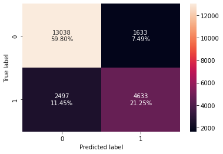

```python
# creating confusion matrix
confusion_matrix_statsmodels(lg4, X_train8, y_train)
```

```python
log_reg_model_train_perf = model_performance_classification_statsmodels(
    lg4, X_train8, y_train
)

print("Training performance:")
log_reg_model_train_perf
```

```
Training performance:
```

|  | Accuracy | Recall | Precision | F1 |
| --- | --- | --- | --- | --- |
| 0 | 0.810559 | 0.64979 | 0.739387 | 0.691699 |

#### ROC-AUC

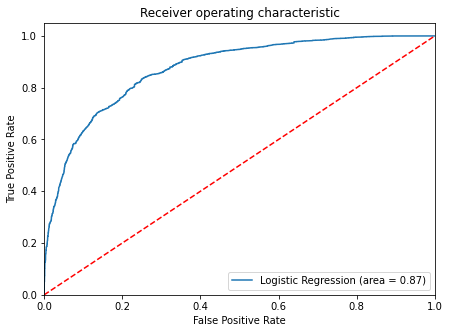

```python
logit_roc_auc_train = roc_auc_score(y_train, lg4.predict(X_train8))
fpr, tpr, thresholds = roc_curve(y_train, lg4.predict(X_train8))
plt.figure(figsize=(7, 5))
plt.plot(fpr, tpr, label="Logistic Regression (area = %0.2f)" % logit_roc_auc_train)
plt.plot([0, 1], [0, 1], "r--")
plt.xlim([0.0, 1.0])
plt.ylim([0.0, 1.05])
plt.xlabel("False Positive Rate")
plt.ylabel("True Positive Rate")
plt.title("Receiver operating characteristic")
plt.legend(loc="lower right")
plt.show()
```

#### Observation:

Logistic Regression model has a fairly good recall and ROC-AUC score.

#### Using Precision-Recall curve to find a threshold

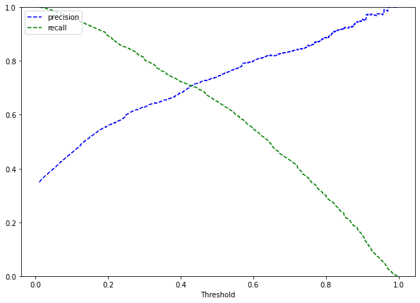

```python
y_scores = lg4.predict(X_train8)
prec, rec, tre = precision_recall_curve(y_train, y_scores,)


def plot_prec_recall_vs_tresh(precisions, recalls, thresholds):
    plt.plot(thresholds, precisions[:-1], "b--", label="precision")
    plt.plot(thresholds, recalls[:-1], "g--", label="recall")
    plt.xlabel("Threshold")
    plt.legend(loc="upper left")
    plt.ylim([0, 1])


plt.figure(figsize=(10, 7))
plot_prec_recall_vs_tresh(prec, rec, tre)
plt.show()
```

At threshold around 0.4 we will get equal precision and recall

```python
# setting the threshold
optimal_threshold_curve = 0.4
```

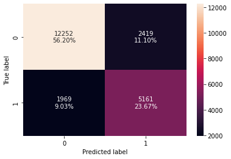

```python
# creating confusion matrix
confusion_matrix_statsmodels(lg4, X_train8, y_train, threshold=optimal_threshold_curve)
```

```python
log_reg_model_train_perf_threshold_curve = model_performance_classification_statsmodels(
    lg4, X_train8, y_train, threshold=optimal_threshold_curve
)
print("Training performance:")
log_reg_model_train_perf_threshold_curve
```

```
Training performance:
```

|  | Accuracy | Recall | Precision | F1 |
| --- | --- | --- | --- | --- |
| 0 | 0.798725 | 0.723843 | 0.680871 | 0.7017 |

#### Observation

Recall has improved as compared to the initial model

### Performance on the test set

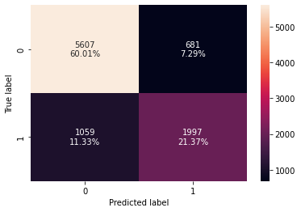

```python
X_test8 = X_test[X_train8.columns].astype(float)
# creating confusion matrix
confusion_matrix_statsmodels(lg4, X_test8, y_test)
```

```python
log_reg_model_test_perf = model_performance_classification_statsmodels(
    lg4, X_test8, y_test
)

print("Test performance:")
log_reg_model_test_perf
```

```
Test performance:
```

|  | Accuracy | Recall | Precision | F1 |
| --- | --- | --- | --- | --- |
| 0 | 0.813784 | 0.653469 | 0.745706 | 0.696547 |

### Using model with threshold = 0.4 from Precision-Recall curve to check performance on test set

```python
log_reg_model_test_perf_threshold_curve = model_performance_classification_statsmodels(
    lg4, X_test8, y_test, threshold=optimal_threshold_curve
)
print("Test performance:")
log_reg_model_test_perf_threshold_curve
```

```
Test performance:
```

|  | Accuracy | Recall | Precision | F1 |
| --- | --- | --- | --- | --- |
| 0 | 0.796768 | 0.718259 | 0.678936 | 0.698044 |

## Final Model Summary

```python
print(lg4.summary())
```

```
                           Logit Regression Results
==============================================================================
Dep. Variable:         booking_status   No. Observations:                21801
Model:                          Logit   Df Residuals:                    21774
Method:                           MLE   Df Model:                           26
Date:                Fri, 13 May 2022   Pseudo R-squ.:                  0.3520
Time:                        22:09:49   Log-Likelihood:                -8929.4
converged:                       True   LL-Null:                       -13780.
Covariance Type:            nonrobust   LLR p-value:                     0.000
==================================================================================================
                                     coef    std err          z      P>|z|      [0.025      0.975]
--------------------------------------------------------------------------------------------------
const                             -5.5316      0.122    -45.368      0.000      -5.771      -5.293
no_of_children                     0.1898      0.062      3.080      0.002       0.069       0.311
no_of_weekend_nights               0.1264      0.022      5.789      0.000       0.084       0.169
no_of_week_nights                  0.0374      0.014      2.728      0.006       0.011       0.064
lead_time                          0.0161      0.000     56.286      0.000       0.016       0.017
no_of_previous_cancellations       0.1725      0.087      1.978      0.048       0.002       0.343
avg_price_per_room                 0.0212      0.001     26.084      0.000       0.020       0.023
no_of_special_requests            -1.4797      0.033    -45.023      0.000      -1.544      -1.415
required_car_parking_space_1      -1.5633      0.150    -10.408      0.000      -1.858      -1.269
room_type_reserved_Room_Type 2    -0.3958      0.135     -2.921      0.003      -0.661      -0.130
room_type_reserved_Room_Type 4    -0.2147      0.053     -4.083      0.000      -0.318      -0.112
room_type_reserved_Room_Type 5    -0.4647      0.213     -2.187      0.029      -0.881      -0.048
room_type_reserved_Room_Type 6    -1.0027      0.154     -6.499      0.000      -1.305      -0.700
room_type_reserved_Room_Type 7    -1.5672      0.310     -5.049      0.000      -2.175      -0.959
arrival_year_2018                  0.2651      0.063      4.218      0.000       0.142       0.388
arrival_month_2                    1.1191      0.107     10.496      0.000       0.910       1.328
arrival_month_3                    0.8470      0.093      9.083      0.000       0.664       1.030
arrival_month_4                    0.5220      0.084      6.209      0.000       0.357       0.687
arrival_month_5                    0.2716      0.084      3.232      0.001       0.107       0.436
arrival_month_6                    0.3654      0.077      4.735      0.000       0.214       0.517
arrival_month_7                    0.3208      0.081      3.985      0.000       0.163       0.479
arrival_month_8                    0.3092      0.077      4.032      0.000       0.159       0.460
arrival_month_10                   0.3912      0.071      5.488      0.000       0.251       0.531
arrival_month_11                   0.7676      0.091      8.471      0.000       0.590       0.945
arrival_month_12                  -1.3479      0.113    -11.934      0.000      -1.569      -1.127
market_segment_type_Online         1.6959      0.051     33.460      0.000       1.597       1.795
repeated_guest_1                  -1.4915      0.477     -3.129      0.002      -2.426      -0.557
==================================================================================================
```

#### Observation

- The model performs well on both training and test data sets
- The highest recall is 72% on the training set.
- Using the model with default threshold the model will give a low recall but good precision scores.
- Using the model with 0.4 threshold the model will give a balance recall and precision score - This model will help the bank to maintain a balance in identifying potential customer and the cost of resources.

## Building a Decision Tree model

### Split Data

```python
X = df1.drop(["booking_status"], axis=1)
y = df1["booking_status"]
```

```python
# encoding the categorical variables
X = pd.get_dummies(X, drop_first=True)
X.head()
```

|  | no_of_adults | no_of_children | no_of_weekend_nights | no_of_week_nights | lead_time | no_of_previous_cancellations | no_of_previous_bookings_not_canceled | avg_price_per_room | no_of_special_requests | required_car_parking_space_1 | room_type_reserved_Room_Type 2 | room_type_reserved_Room_Type 3 | room_type_reserved_Room_Type 4 | room_type_reserved_Room_Type 5 | room_type_reserved_Room_Type 6 | room_type_reserved_Room_Type 7 | arrival_year_2018 | arrival_month_2 | arrival_month_3 | arrival_month_4 | arrival_month_5 | arrival_month_6 | arrival_month_7 | arrival_month_8 | arrival_month_9 | arrival_month_10 | arrival_month_11 | arrival_month_12 | market_segment_type_Complementary | … |
| --- | --- | --- | --- | --- | --- | --- | --- | --- | --- | --- | --- | --- | --- | --- | --- | --- | --- | --- | --- | --- | --- | --- | --- | --- | --- | --- | --- | --- | --- | --- |
| 0 | 2 | 0 | 1 | 2 | 224 | 0 | 0 | 65.00 | 0 | 0 | 0 | 0 | 0 | 0 | 0 | 0 | 0 | 0 | 0 | 0 | 0 | 0 | 0 | 0 | 0 | 1 | 0 | 0 | 0 | … |
| 2 | 1 | 0 | 2 | 1 | 1 | 0 | 0 | 60.00 | 0 | 0 | 0 | 0 | 0 | 0 | 0 | 0 | 1 | 1 | 0 | 0 | 0 | 0 | 0 | 0 | 0 | 0 | 0 | 0 | 0 | … |
| 3 | 2 | 0 | 0 | 2 | 211 | 0 | 0 | 100.00 | 0 | 0 | 0 | 0 | 0 | 0 | 0 | 0 | 1 | 0 | 0 | 0 | 1 | 0 | 0 | 0 | 0 | 0 | 0 | 0 | 0 | … |
| 5 | 2 | 0 | 0 | 2 | 346 | 0 | 0 | 115.00 | 1 | 0 | 0 | 0 | 0 | 0 | 0 | 0 | 1 | 0 | 0 | 0 | 0 | 0 | 0 | 0 | 1 | 0 | 0 | 0 | 0 | … |
| 6 | 2 | 0 | 1 | 3 | 34 | 0 | 0 | 107.55 | 1 | 0 | 0 | 0 | 0 | 0 | 0 | 0 | 0 | 0 | 0 | 0 | 0 | 0 | 0 | 0 | 0 | 1 | 0 | 0 | 0 | … |

```python
X_train, X_test, y_train, y_test = train_test_split(X, y, test_size=0.4, random_state=1)
```

```python
print("Number of rows in train data =", X_train.shape[0])
print("Number of rows in test data =", X_test.shape[0])
print("Percentage of classes in training set:")
print(y_train.value_counts(normalize=True))
print("Percentage of classes in test set:")
print(y_test.value_counts(normalize=True))
```

```
Number of rows in train data = 18687
Number of rows in test data = 12458
Percentage of classes in training set:
0    0.670359
1    0.329641
Name: booking_status, dtype: float64
Percentage of classes in test set:
0    0.676834
1    0.323166
Name: booking_status, dtype: float64
```

```python
# defining a function to compute different metrics to check performance of a classification model built using sklearn
def model_performance_classification_sklearn(model, predictors, target):
    """
    Function to compute different metrics to check classification model performance

    model: classifier
    predictors: independent variables
    target: dependent variable
    """

    # predicting using the independent variables
    pred = model.predict(predictors)

    acc = accuracy_score(target, pred)  # to compute Accuracy
    recall = recall_score(target, pred)  # to compute Recall
    precision = precision_score(target, pred)  # to compute Precision
    f1 = f1_score(target, pred)  # to compute F1-score

    # creating a dataframe of metrics
    df_perf = pd.DataFrame(
        {"Accuracy": acc, "Recall": recall, "Precision": precision, "F1": f1,},
        index=[0],
    )

    return df_perf
```

```python
## Function to create confusion matrix
def make_confusion_matrix(model, y_actual, labels=[1, 0]):
    """
    model : classifier to predict values of X
    y_actual : ground truth

    """
    y_predict = model.predict(X_test)
    cm = metrics.confusion_matrix(y_actual, y_predict, labels=[0, 1])
    df_cm = pd.DataFrame(
        cm,
        index=[i for i in ["Actual - No", "Actual - Yes"]],
        columns=[i for i in ["Predicted - No", "Predicted - Yes"]],
    )
    group_counts = ["{0:0.0f}".format(value) for value in cm.flatten()]
    group_percentages = ["{0:.2%}".format(value) for value in cm.flatten() / np.sum(cm)]
    labels = [f"{v1}\n{v2}" for v1, v2 in zip(group_counts, group_percentages)]
    labels = np.asarray(labels).reshape(2, 2)
    plt.figure(figsize=(10, 7))
    sns.heatmap(df_cm, annot=labels, fmt="")
    plt.ylabel("True label")
    plt.xlabel("Predicted label")
```

```python
def confusion_matrix_sklearn(model, predictors, target):
    """
    To plot the confusion_matrix with percentages

    model: classifier
    predictors: independent variables
    target: dependent variable
    """
    y_pred = model.predict(predictors)
    cm = confusion_matrix(target, y_pred)
    labels = np.asarray(
        [
            ["{0:0.0f}".format(item) + "\n{0:.2%}".format(item / cm.flatten().sum())]
            for item in cm.flatten()
        ]
    ).reshape(2, 2)

    plt.figure(figsize=(6, 4))
    sns.heatmap(cm, annot=labels, fmt="")
    plt.ylabel("True label")
    plt.xlabel("Predicted label")
```

```python
##  Function to calculate recall score
def get_recall_score(model):
    """
    model : classifier to predict values of X

    """
    pred_train = model.predict(X_train)
    pred_test = model.predict(X_test)
    print("Recall on training set : ", metrics.recall_score(y_train, pred_train))
    print("Recall on test set : ", metrics.recall_score(y_test, pred_test))
```

### Decision Tree Model

```python
model = DecisionTreeClassifier(criterion="gini", random_state=1)
model.fit(X_train, y_train)
```

```
DecisionTreeClassifier(random_state=1)
```

```python
decision_tree_perf_train = model_performance_classification_sklearn(
    model, X_train, y_train
)
decision_tree_perf_train
```

|  | Accuracy | Recall | Precision | F1 |
| --- | --- | --- | --- | --- |
| 0 | 0.993471 | 0.984253 | 0.995894 | 0.990039 |

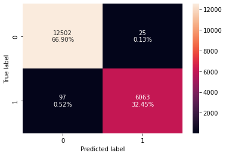

```python
confusion_matrix_sklearn(model, X_train, y_train)
```

#### Checking model performance on test set

```python
decision_tree_perf_test = model_performance_classification_sklearn(
    model, X_test, y_test
)
decision_tree_perf_test
```

|  | Accuracy | Recall | Precision | F1 |
| --- | --- | --- | --- | --- |
| 0 | 0.87197 | 0.806011 | 0.799458 | 0.802721 |

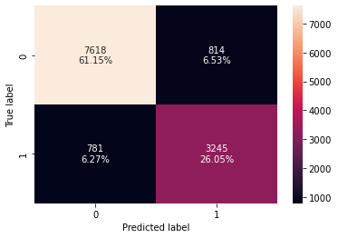

```python
confusion_matrix_sklearn(model, X_test, y_test)
```

```python
# Recall on train and test
get_recall_score(model)
```

```
Recall on training set :  0.9842532467532468
Recall on test set :  0.8060109289617486
```

### Visualizing the Decision Tree

```python
feature_names = list(X.columns)
print(feature_names)
```

```
['no_of_adults', 'no_of_children', 'no_of_weekend_nights', 'no_of_week_nights', 'lead_time', 'no_of_previous_cancellations', 'no_of_previous_bookings_not_canceled', 'avg_price_per_room', 'no_of_special_requests', 'required_car_parking_space_1', 'room_type_reserved_Room_Type 2', 'room_type_reserved_R…
```

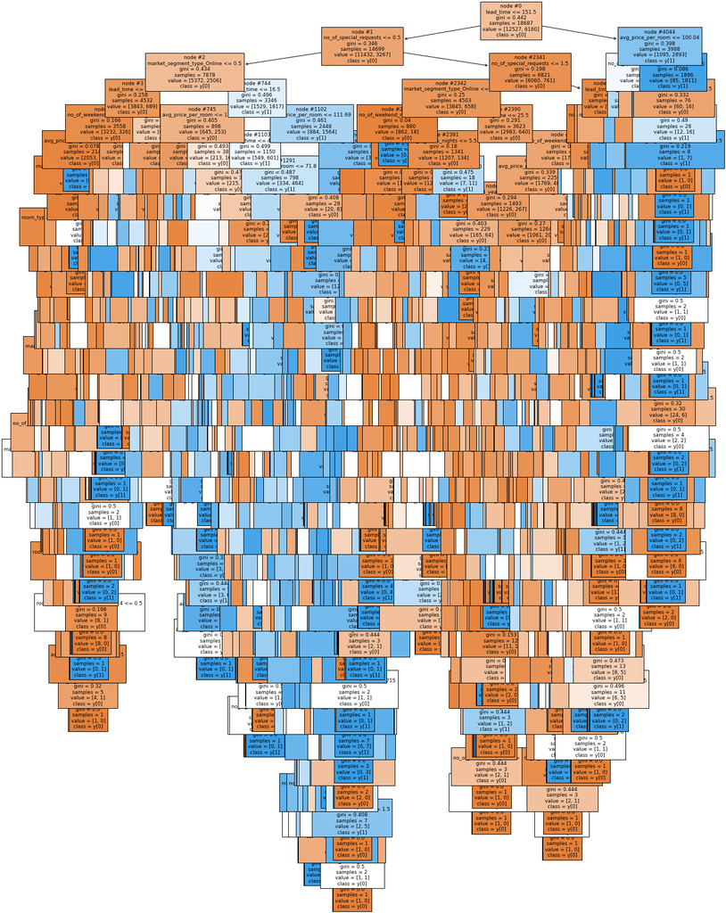

```python
plt.figure(figsize=(20, 30))
tree.plot_tree(
    model,
    feature_names=feature_names,
    filled=True,
    fontsize=9,
    node_ids=True,
    class_names=True,
)
plt.show()
```

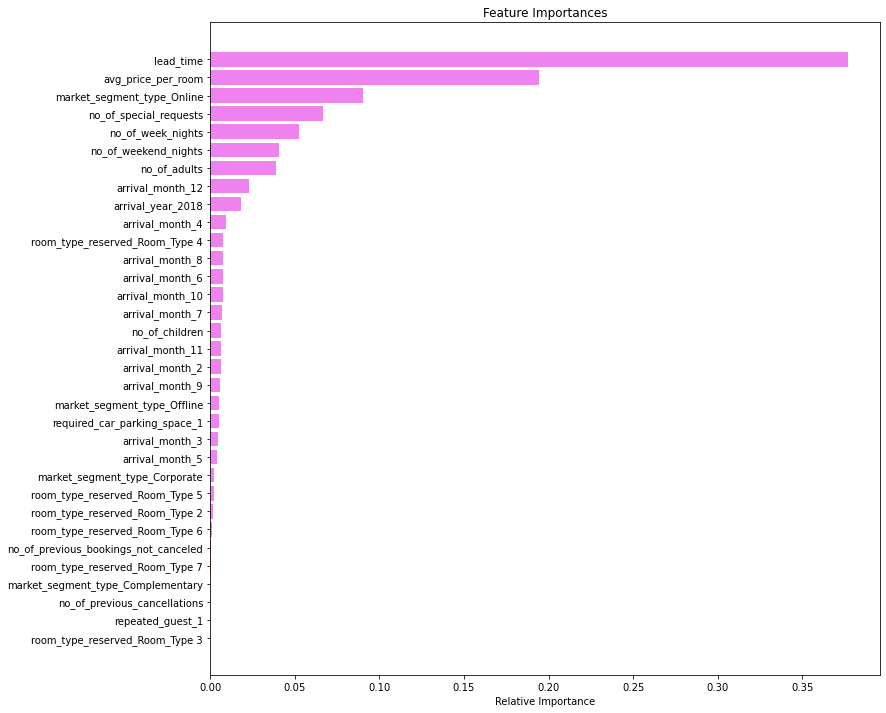

```python
importances = model.feature_importances_
indices = np.argsort(importances)

plt.figure(figsize=(12, 12))
plt.title("Feature Importances")
plt.barh(range(len(indices)), importances[indices], color="violet", align="center")
plt.yticks(range(len(indices)), [feature_names[i] for i in indices])
plt.xlabel("Relative Importance")
plt.show()
```

## Do we need to prune the tree?

#### Ans: Yes, pruning of this decision tree needs to be done to prevent overfitting

## Pre-Pruning:

```python
model1 = DecisionTreeClassifier(criterion="gini", max_depth=3, random_state=1)
model1.fit(X_train, y_train)
```

```
DecisionTreeClassifier(max_depth=3, random_state=1)
```

### Confusion Matrix - decision tree with depth restricted to 3

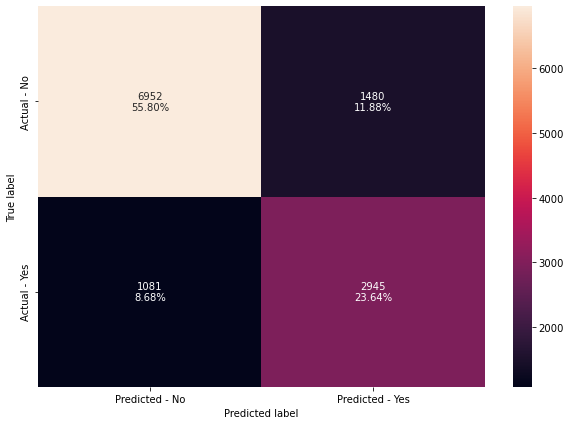

```python
make_confusion_matrix(model1, y_test)
```

```python
# Accuracy on train and test
print("Accuracy on training set : ", model1.score(X_train, y_train))
print("Accuracy on test set : ", model1.score(X_test, y_test))
# Recall on train and test
get_recall_score(model1)
```

```
Accuracy on training set :  0.7993792476052871
Accuracy on test set :  0.7944292823888265
Recall on training set :  0.7373376623376623
Recall on test set :  0.7314952806756085
```

#### Observation:

Although both accuracy and recall have reduced in the pre-pruned tree model, the performance on training and test sets are similar which makes it a good generalized model.

## Visualizing the Pre-pruned Decision Tree

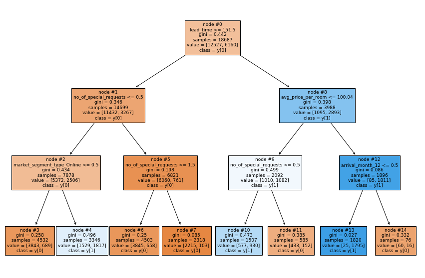

```python
plt.figure(figsize=(15, 10))

tree.plot_tree(
    model1,
    feature_names=feature_names,
    filled=True,
    fontsize=9,
    node_ids=True,
    class_names=True,
)
plt.show()
```

```python
# importance features
print(
    pd.DataFrame(
        model1.feature_importances_, columns=["Imp"], index=X_train.columns
    ).sort_values(by="Imp", ascending=False)
)
```

```
                                           Imp
lead_time                             0.512809
market_segment_type_Online            0.190019
no_of_special_requests                0.145644
avg_price_per_room                    0.123181
arrival_month_12                      0.028347
arrival_month_10                      0.000000
arrival_month_5                       0.000000
arrival_month_6                       0.000000
arrival_month_7                       0.000000
arrival_month_8                       0.000000
arrival_month_9                       0.000000
no_of_adults                          0.000000
arrival_month_11                      0.000000
arrival_month_3                       0.000000
market_segment_type_Complementary     0.000000
market_segment_type_Corporate         0.000000
market_segment_type_Offline           0.000000
arrival_month_4                       0.000000
arrival_year_2018                     0.000000
arrival_month_2                       0.000000
no_of_children                        0.000000
room_type_reserved_Room_Type 7        0.000000
room_type_reserved_Room_Type 6        0.000000
room_type_reserved_Room_Type 5        0.000000
room_type_reserved_Room_Type 4        0.000000
room_type_reserved_Room_Type 3        0.000000
room_type_reserved_Room_Type 2        0.000000
required_car_parking_space_1          0.000000
no_of_previous_bookings_not_canceled  0.000000
no_of_previous_cancellations          0.000000
no_of_week_nights                     0.000000
no_of_weekend_nights                  0.000000
repeated_guest_1                      0.000000
```

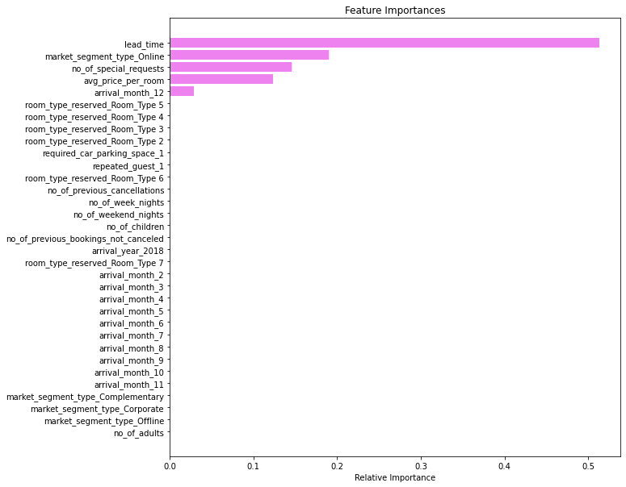

```python
importances = model1.feature_importances_
indices = np.argsort(importances)

plt.figure(figsize=(10, 10))
plt.title("Feature Importances")
plt.barh(range(len(indices)), importances[indices], color="violet", align="center")
plt.yticks(range(len(indices)), [feature_names[i] for i in indices])
plt.xlabel("Relative Importance")
plt.show()
```